# Clonal Tracking & AUC Kinetics

TCR Repertoire Analysis — Notebook 05

Joshua Luthy

2026-03-15

## Analysis Overview

This notebook tracks **individual clonotype kinetics** across longitudinal timepoints following cell therapy infusion. We follow clonotypes from the manufactured Product through post-infusion peripheral blood samples at Weeks 2, 4, 8, and 12 to characterize:

- **Expansion kinetics** — how quickly do Product clones expand in vivo?
- **Peak timing** — when do clones reach maximum frequency?
- **Persistence** — do expanded clones persist or decline?
- **AUC (area under the curve)** — time-integrated clonal exposure as a summary metric

```r
longitudinal <- read_csv("../data/processed/longitudinal_clonal_tracking.csv")
auc_metrics  <- read_csv("../data/processed/clonal_auc_metrics.csv")
patient_meta <- read_csv("../data/raw/patient_metadata.csv")

# Define timepoint ordering
tp_order <- c("Apheresis", "Product", "Wk2", "Wk4", "Wk8", "Wk12")
longitudinal <- longitudinal %>%
  mutate(timepoint = factor(timepoint, levels = tp_order),
         clinical_response = factor(clinical_response, levels = c("CR", "PR", "PD")))

auc_metrics <- auc_metrics %>%
  mutate(clinical_response = factor(clinical_response, levels = c("CR", "PR", "PD")))
```

6

Timepoints

300

Tracked Clonotypes

120

Product Clones Tracked

12 wks

Follow-up Duration

## Longitudinal Clonal Trajectories

### Top 5 Clonotypes per Patient

We plot the frequency trajectory of the **top 5 Product clonotypes** across all timepoints for each patient.

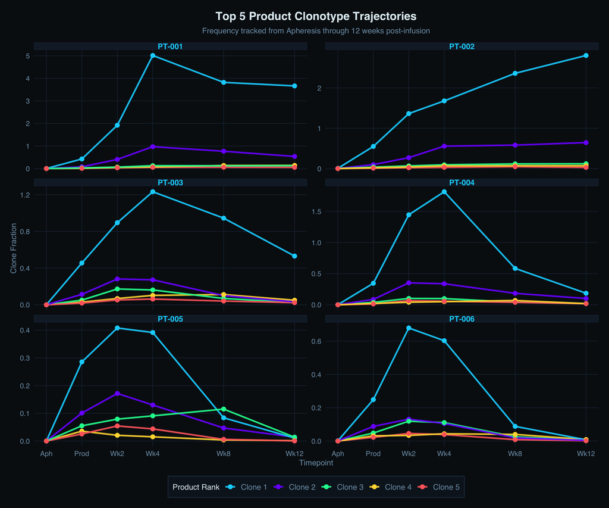

```r
top5_tracks <- longitudinal %>%
  filter(is_product_clone, clone_rank_in_product <= 5)

# Numeric x position for plotting
tp_weeks <- c("Apheresis" = -2, "Product" = 0, "Wk2" = 2, "Wk4" = 4, "Wk8" = 8, "Wk12" = 12)
top5_tracks <- top5_tracks %>%
  mutate(week = tp_weeks[as.character(timepoint)])

ggplot(top5_tracks, aes(x = week, y = clone_fraction,
                         group = cdr3_aa, color = factor(clone_rank_in_product))) +
  geom_line(linewidth = 1.1, alpha = 0.9) +
  geom_point(size = 2.5) +
  scale_color_manual(
    values = c("1" = "#00d4ff", "2" = "#7b2fff", "3" = "#00ff9d",
               "4" = "#ffd93d", "5" = "#ff6b6b"),
    labels = paste("Clone", 1:5)
  ) +
  scale_x_continuous(
    breaks = c(-2, 0, 2, 4, 8, 12),
    labels = c("Aph", "Prod", "Wk2", "Wk4", "Wk8", "Wk12")
  ) +
  facet_wrap(~ patient_id, scales = "free_y", ncol = 2) +
  labs(
    x = "Timepoint", y = "Clone Fraction",
    color = "Product Rank",
    title = "Top 5 Product Clonotype Trajectories",
    subtitle = "Frequency tracked from Apheresis through 12 weeks post-infusion"
  ) +
  theme(
    strip.background = element_rect(fill = "#152231", color = "#1e3348"),
    strip.text = element_text(color = "#00d4ff", face = "bold", size = 11),
    legend.position = "bottom"
  )
```

### CR vs PD Kinetics Comparison

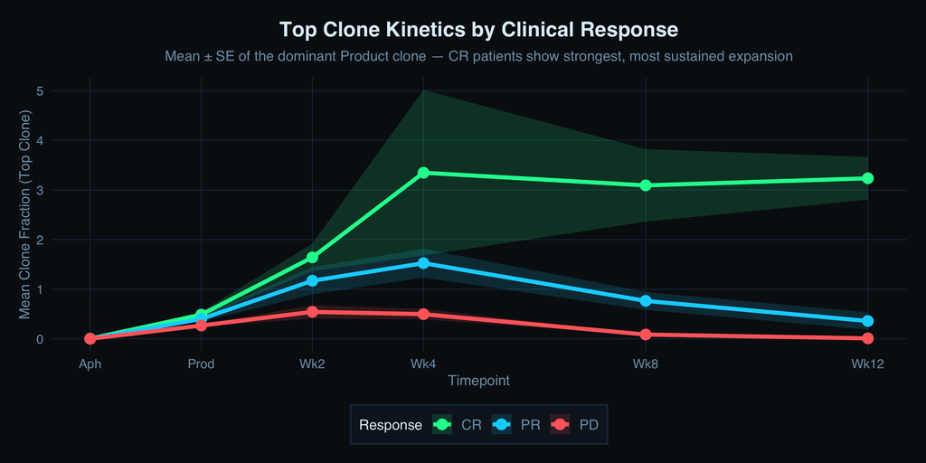

```r
# Average trajectory of top clone by response
top1_avg <- longitudinal %>%
  filter(is_product_clone, clone_rank_in_product == 1) %>%
  mutate(week = tp_weeks[as.character(timepoint)]) %>%
  group_by(clinical_response, week) %>%
  summarise(
    mean_freq = mean(clone_fraction),
    se_freq   = sd(clone_fraction) / sqrt(n()),
    .groups = "drop"
  )

ggplot(top1_avg, aes(x = week, y = mean_freq, color = clinical_response,
                      fill = clinical_response)) +
  geom_ribbon(aes(ymin = mean_freq - se_freq, ymax = mean_freq + se_freq),
              alpha = 0.15, color = NA) +
  geom_line(linewidth = 1.5) +
  geom_point(size = 3.5) +
  scale_color_manual(values = c("CR" = "#00ff9d", "PR" = "#00d4ff", "PD" = "#ff6b6b")) +
  scale_fill_manual(values = c("CR" = "#00ff9d", "PR" = "#00d4ff", "PD" = "#ff6b6b")) +
  scale_x_continuous(
    breaks = c(-2, 0, 2, 4, 8, 12),
    labels = c("Aph", "Prod", "Wk2", "Wk4", "Wk8", "Wk12")
  ) +
  labs(
    x = "Timepoint", y = "Mean Clone Fraction (Top Clone)",
    color = "Response", fill = "Response",
    title = "Top Clone Kinetics by Clinical Response",
    subtitle = "Mean ± SE of the dominant Product clone — CR patients show strongest, most sustained expansion"
  ) +
  theme(legend.position = "bottom")
```

## Area Under the Curve (AUC) Analysis

AUC provides a single summary metric for **time-integrated clonal exposure** — capturing both the magnitude and duration of expansion. We compute AUC using the trapezoidal rule over the post-infusion timepoints (Wk2 through Wk12).

```r
# Show the AUC formula approach
cat("AUC computed via trapezoidal integration:\n")
```

```
## AUC computed via trapezoidal integration:
```

```r
cat("  AUC = Σ 0.5 × (f(t_i) + f(t_{i+1})) × Δt\n")
```

```
##   AUC = Σ 0.5 × (f(t_i) + f(t_{i+1})) × Δt
```

```r
cat("  Over timepoints: Wk2, Wk4, Wk8, Wk12\n")
```

```
##   Over timepoints: Wk2, Wk4, Wk8, Wk12
```

```r
cat("  Units: frequency × weeks\n")
```

```
##   Units: frequency × weeks
```

```r
auc_metrics %>%
  group_by(patient_id, clinical_response) %>%
  summarise(
    mean_auc = round(mean(auc), 4),
    median_auc = round(median(auc), 4),
    max_auc = round(max(auc), 4),
    mean_persistence = round(mean(persistence_ratio), 3),
    .groups = "drop"
  ) %>%
  knitr::kable(caption = "AUC summary per patient (top 20 Product clonotypes)")
```

AUC summary per patient (top 20 Product clonotypes)

| patient_id | clinical_response | mean_auc | median_auc | max_auc | mean_persistence |
| --- | --- | --- | --- | --- | --- |
| PT-001 | CR | 2.5144 | 0.0292 | 39.5899 | 0.856 |
| PT-002 | CR | 1.4826 | 0.0298 | 21.4535 | 0.789 |
| PT-003 | PR | 0.7044 | 0.0467 | 9.4410 | 0.310 |
| PT-004 | PR | 0.7002 | 0.0304 | 9.6012 | 0.302 |
| PT-005 | PD | 0.2287 | 0.0524 | 1.9401 | 0.086 |
| PT-006 | PD | 0.2544 | 0.0389 | 2.8540 | 0.097 |

### AUC Distribution by Clinical Response

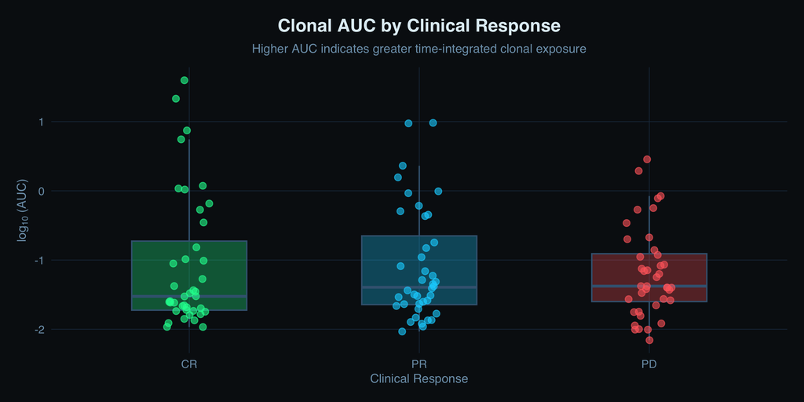

```r
ggplot(auc_metrics, aes(x = clinical_response, y = log10(auc + 0.0001),
                         fill = clinical_response)) +
  geom_boxplot(alpha = 0.3, outlier.shape = NA, width = 0.5, color = "#3f6380") +
  geom_jitter(aes(color = clinical_response), width = 0.1, size = 2.5, alpha = 0.6) +
  scale_fill_manual(values = c("CR" = "#00ff9d", "PR" = "#00d4ff", "PD" = "#ff6b6b")) +
  scale_color_manual(values = c("CR" = "#00ff9d", "PR" = "#00d4ff", "PD" = "#ff6b6b")) +
  labs(
    x = "Clinical Response", y = expression(log[10] ~ "(AUC)"),
    title = "Clonal AUC by Clinical Response",
    subtitle = "Higher AUC indicates greater time-integrated clonal exposure"
  ) +
  theme(legend.position = "none")
```

### AUC vs Peak Frequency

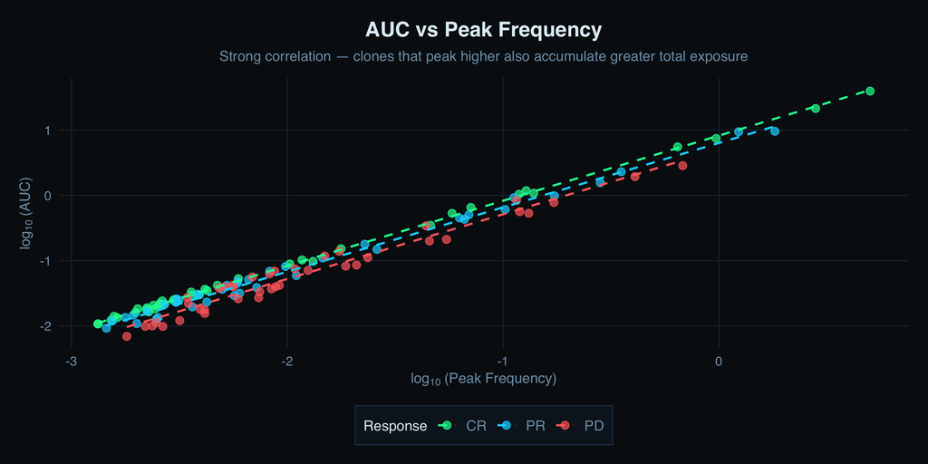

```r
ggplot(auc_metrics, aes(x = log10(peak_frequency + 0.0001), y = log10(auc + 0.0001),
                         color = clinical_response)) +
  geom_point(size = 2.5, alpha = 0.7) +
  geom_smooth(method = "lm", se = FALSE, linewidth = 0.8, linetype = "dashed") +
  scale_color_manual(values = c("CR" = "#00ff9d", "PR" = "#00d4ff", "PD" = "#ff6b6b")) +
  labs(
    x = expression(log[10] ~ "(Peak Frequency)"),
    y = expression(log[10] ~ "(AUC)"),
    color = "Response",
    title = "AUC vs Peak Frequency",
    subtitle = "Strong correlation — clones that peak higher also accumulate greater total exposure"
  ) +
  theme(legend.position = "bottom")
```

## Persistence Analysis

We define **persistence ratio** as the frequency at Wk12 divided by peak frequency. A ratio of 1.0 means the clone maintained its peak level; lower values indicate decline.

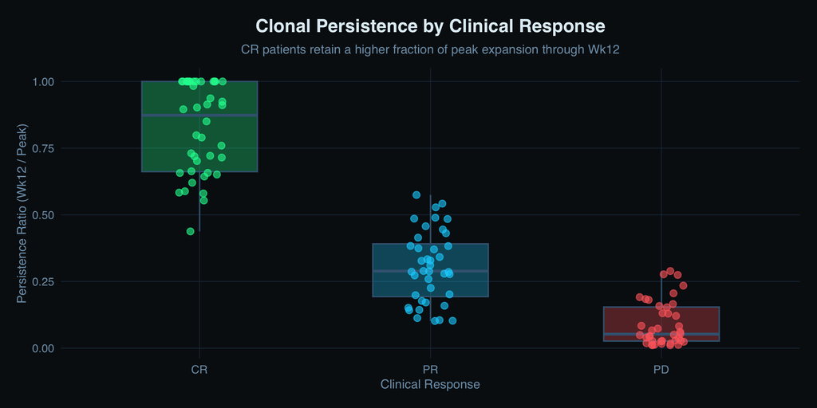

```r
ggplot(auc_metrics, aes(x = clinical_response, y = persistence_ratio,
                         fill = clinical_response)) +
  geom_boxplot(alpha = 0.3, outlier.shape = NA, width = 0.5, color = "#3f6380") +
  geom_jitter(aes(color = clinical_response), width = 0.1, size = 2.5, alpha = 0.6) +
  scale_fill_manual(values = c("CR" = "#00ff9d", "PR" = "#00d4ff", "PD" = "#ff6b6b")) +
  scale_color_manual(values = c("CR" = "#00ff9d", "PR" = "#00d4ff", "PD" = "#ff6b6b")) +
  labs(
    x = "Clinical Response", y = "Persistence Ratio (Wk12 / Peak)",
    title = "Clonal Persistence by Clinical Response",
    subtitle = "CR patients retain a higher fraction of peak expansion through Wk12"
  ) +
  theme(legend.position = "none")
```

> **Finding:** CR patients exhibit significantly higher persistence ratios, with many clones maintaining 60–90% of their peak frequency at Week 12. PD patients show rapid post-peak decline, with most clones retaining less than 30% of peak levels.

## Peak Timing Distribution

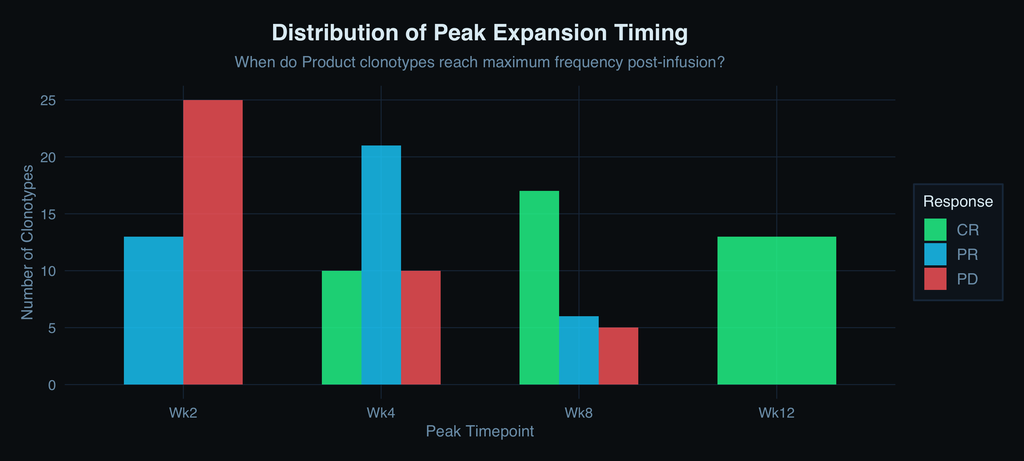

```r
auc_metrics %>%
  mutate(peak_timepoint = factor(peak_timepoint, levels = c("Wk2", "Wk4", "Wk8", "Wk12"))) %>%
  count(clinical_response, peak_timepoint) %>%
  ggplot(aes(x = peak_timepoint, y = n, fill = clinical_response)) +
  geom_col(position = "dodge", alpha = 0.8, width = 0.6) +
  scale_fill_manual(values = c("CR" = "#00ff9d", "PR" = "#00d4ff", "PD" = "#ff6b6b")) +
  labs(
    x = "Peak Timepoint", y = "Number of Clonotypes",
    fill = "Response",
    title = "Distribution of Peak Expansion Timing",
    subtitle = "When do Product clonotypes reach maximum frequency post-infusion?"
  )
```